# Why use Linear REGRESSION IN THIS CASE:

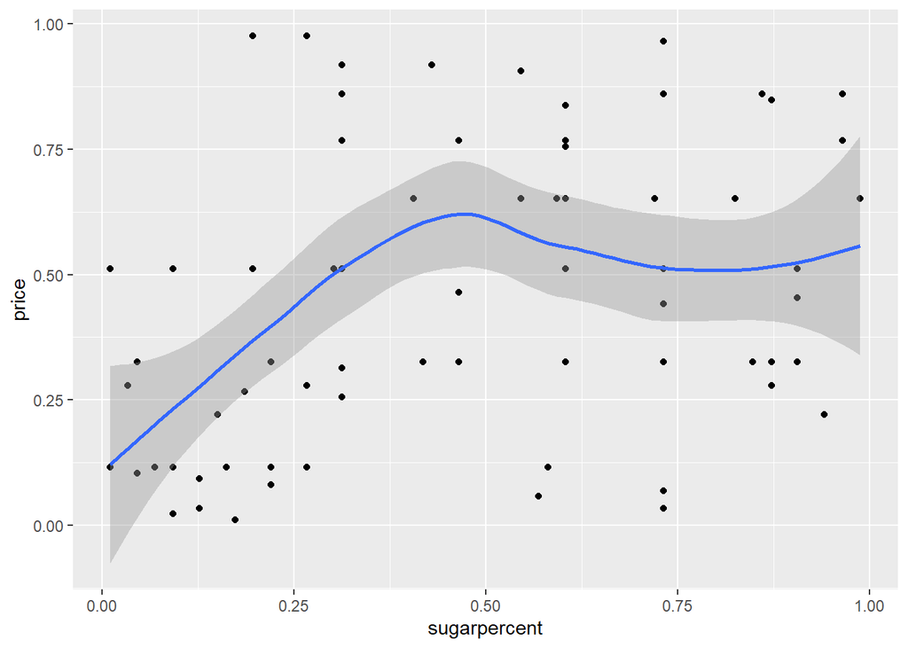

```r
CandyData%>%ggplot(aes(x=sugarpercent, y = price))+geom_point()+geom_smooth()+
  labs("Price vs SugarPercentage")
```

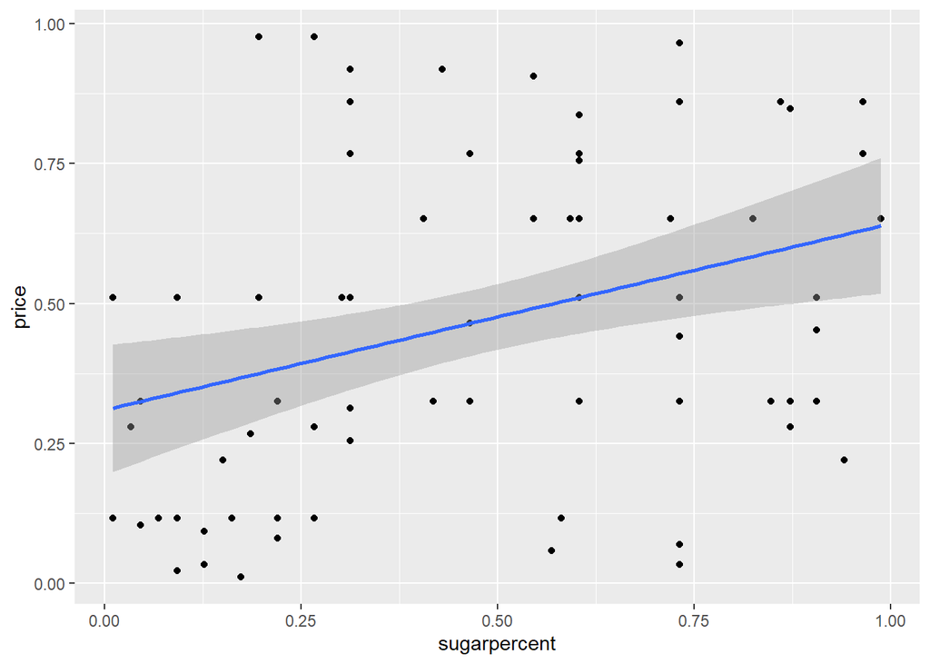

```r
CandyData%>%ggplot(aes(x=sugarpercent, y = price))+geom_point()+
  geom_smooth(method = "lm")+
  labs("Using linear model to show trend")
```

# section c.

In this section we are supposed to add “Fruity” to the logistic regression model. Here few thing to observe are; P- value changed for “Nougat” and “Price”. Nougat P-value is 0.996 which insignificant with negative coefficient and negative Z value. P value of Nougat changed because of is negative values in coefficient and z-value. Estimate Std. Error z value Pr(>|z|)  
nougat -0.0001002 0.0179737 -0.006 0.996

```r
logit2=glm(cbind(Nwins, Nlosses)~chocolate+sugarpercent+nougat+bar+price+fruity , data  = CandyData, family = binomial)
par(mfrow=c(2,2))
summary(logit2)
```

```
##
## Call:
## glm(formula = cbind(Nwins, Nlosses) ~ chocolate + sugarpercent +
##     nougat + bar + price + fruity, family = binomial, data = CandyData)
##
## Deviance Residuals:
##     Min       1Q   Median       3Q      Max
## -27.143   -8.398   -1.426    7.824   30.492
##
## Coefficients:
##                Estimate Std. Error z value Pr(>|z|)
## (Intercept)  -0.6379564  0.0134871 -47.301  < 2e-16 ***
## chocolate     0.8749712  0.0135241  64.697  < 2e-16 ***
## sugarpercent  0.3540613  0.0155072  22.832  < 2e-16 ***
## nougat       -0.0001002  0.0179737  -0.006    0.996
## bar           0.1483741  0.0143334  10.352  < 2e-16 ***
## price        -0.0944633  0.0186976  -5.052 4.37e-07 ***
## fruity        0.2440131  0.0124881  19.540  < 2e-16 ***
## ---
## Signif. codes:  0 '***' 0.001 '**' 0.01 '*' 0.05 '.' 0.1 ' ' 1
##
## (Dispersion parameter for binomial family taken to be 1)
##
##     Null deviance: 22682  on 84  degrees of freedom
## Residual deviance: 12674  on 78  degrees of freedom
## AIC: 13398
##
## Number of Fisher Scoring iterations: 4
```

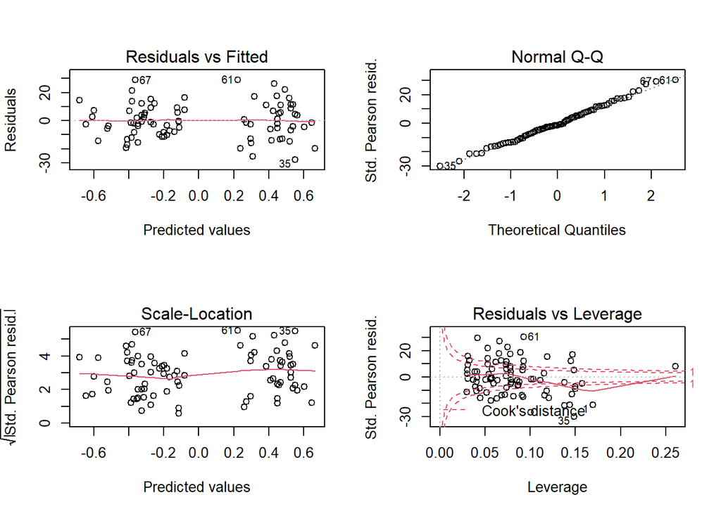

```r
plot(logit2)
```

```r
confint.default(logit2)
```

```
##                    2.5 %      97.5 %
## (Intercept)  -0.66439071 -0.61152206
## chocolate     0.84846439  0.90147795
## sugarpercent  0.32366770  0.38445494
## nougat       -0.03532795  0.03512754
## bar           0.12028108  0.17646706
## price        -0.13110998 -0.05781660
## fruity        0.21953690  0.26848937
```